# Mathematics of Machine Learning - Linear Regression

### Imports

```python
import numpy as np
import pandas as pd
from sklearn import datasets
from matplotlib import pyplot as plt
from scipy.stats import norm, lognorm
```

### Getting data

- Load data from sklearn datasets
- Set X,y
- Display data descriptio

```python
# Get Sample Datasets
'''
datasets.load_boston
datasets.load_breast_cancer
datasets.load_diabetes
datasets.load_iris
'''
data_dict = datasets.load_boston()

X = data_dict['data']
y = data_dict['target']
feature_names = data_dict['feature_names']
X_df = pd.DataFrame(X, columns=feature_names)

data_desc =  data_dict['DESCR']
```

### Scalers

```python
def min_max(feature):
    scaled_feature = (feature - feature.min()) / (feature.max() - feature.min())
    return scaled_feature

def stand(feature):
    scaled_feature = (feature - feature.mean()) / feature.std()
    return scaled_feature

def robust(feature):
    iqr = feature.quantile(.75)-feature.quantile(.25)
    scaled_feature = (feature-feature.median()) / iqr
    return scaled_feature

def uniform(feature):
    scaled_feature = feature.rank(method='first') / (feature.shape[0]+1)
    return scaled_feature

def normal(feature):
    scaled_feature = norm.ppf(uniform(feature))
    scaled_feature = pd.DataFrame(scaled_feature, columns = feature.columns)
    return scaled_feature

def lognormal(feature):
    scaled_feature = lognorm.ppf(uniform(feature), 1)
    scaled_feature = pd.DataFrame(scaled_feature, columns = feature.columns)
    return scaled_feature
```

### Linear Regression Model

To define a linear model you only need to provide a vector of coefficients

```python
# Linear regression is just a dot product of X-inputs and b-coefficients.  If the model is fitted with an intercept it is added at the end.
def linear_predict(x_, b_, intercept_=0):
    return np.dot(x_, b_)+intercept_
```

### Mathematics of Linear Regression - Loss Functions

Loss Functions are a parameter of the optimizer and not the linear model

```python
# A common loss function for regression problems is the mean squared error of the prediction
def loss_mse(p_, y_):
    return ((p_-y_)**2).mean()

# A common fit metric for regression problems is the r-squared of the prediction
def r_squared(p_, y_):
    rss = ((p_-y_)**2).mean()
    tss = ((y_.mean()-y_)**2).mean()
    return 1 - rss/tss

# Regularization

# Lasso takes the mean squared error and adds a penalty to the absolute value of the coefficients
def loss_lasso(p_, y_, coefs, l1_=.01 ):
    loss_ = loss_mse(p_, y_)
    loss_ += np.abs(coefs).sum()*l1_
    return loss_

# Ridge takes the mean squared error and adds a penalty to the squared value of the coefficients
def loss_ridge(p_, y_, coefs, l2_=.01):
    loss_ = loss_mse(p_, y_)
    loss_ += (coefs**2).sum()*l2_
    return loss_
```

#### Exercise 1

```python
# Elastic net uses both L1 and L2 penalties;  Copmlete the elastic net loss function
def loss_elasticnet(p_, y_, coefs, alpha=.01, l1_ratio=.5):
    l1_, l2_ = alpha*l1_ratio, alpha*(1-l1_ratio)
    loss_ = loss_mse(p_, y_)
    loss_ += np.abs(coefs).sum()*l1_
    loss_ += (coefs**2).sum()*l2_
    return loss_
```

### Mathematics of Linear Regression - Optimizers

The are a number of optimizers for linear regression:

- Ordinary Least Squares: https://en.wikipedia.org/wiki/Simple_linear_regression#Fitting_the_regression_line

Other optimizers: https://scikit-learn.org/stable/modules/generated/sklearn.linear_model.Ridge.html#sklearn.linear_model.Ridge

- ‘svd’ uses a Singular Value Decomposition of X to compute the Ridge coefficients. More stable for singular matrices than ‘cholesky’.
- ‘cholesky’ uses the standard scipy.linalg.solve function to obtain a closed-form solution.
- ‘sparse_cg’ uses the conjugate gradient solver as found in scipy.sparse.linalg.cg. As an iterative algorithm, this solver is more appropriate than ‘cholesky’ for large-scale data (possibility to set tol and max_iter).
- ‘lsqr’ uses the dedicated regularized least-squares routine scipy.sparse.linalg.lsqr. It is the fastest and uses an iterative procedure.
- ‘sag’ uses a Stochastic Average Gradient descent, and ‘saga’ uses its improved, unbiased version named SAGA. Both methods also use an iterative procedure, and are often faster than other solvers when both n_samples and n_features are large. Note that ‘sag’ and ‘saga’ fast convergence is only guaranteed on features with approximately the same scale. You can preprocess the data with a scaler from sklearn.preprocessing.

#### Optimizer performance visualizations

```python
def plot_bin(act, pred, bin_dim=100, lbls=['Predicted vs Actual','Bin Average','Bin #'], figsize=(10, 5)):
    plt.figure(num=None, figsize=figsize, dpi=80, facecolor='w', edgecolor='k')
    bins = np.array_split(pred.argsort(), bin_dim)
    bins = [[pred[b].mean(), act[b].mean()] for b in bins]
    plt.plot(bins)
    plt.title(lbls[0])
    plt.ylabel(lbls[1])
    plt.xlabel(lbls[2])
    plt.legend = True
    plt.show()
    return bins

def optimizer_summary(opt, x_, y_, name):
    b_, intercept_ = opt(x_, y_)
    p_ = linear_predict(x_, b_, intercept_)
    coefs = np.r_[b_, [intercept_]]
    print(name)
    print(f'   r_squared=       {r_squared(p_, y_):<5.4f}')
    print(f'   loss_mse=        {loss_mse(p_, y_):<8.4f}')
    print(f'   loss_lasso=      {loss_lasso(p_, y_, coefs):<8.4f}')
    print(f'   loss_ridge=      {loss_ridge(p_, y_, coefs):<8.4f}')
    print(f'   loss_elasticnet= {loss_elasticnet(p_, y_, coefs):<8.4f}')
    plot_bin(y_, p_)
```

#### Ordinary least squares

```
Ordinary Least Squares
   r_squared=       0.2324
   loss_mse=        64.8041
   loss_lasso=      65.0830
   loss_ridge=      72.5618
   loss_elasticnet= 68.8224
```

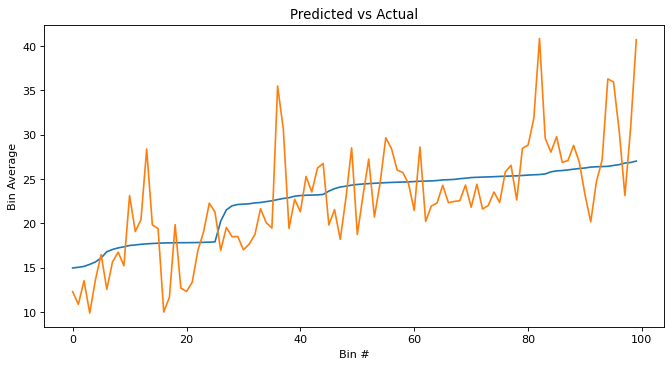

```python
# When penalties are not used and the loss function is mse, OLS can be used.
def ols(x_, y_):
    xm, ym = x_.mean(axis=0), y_.mean()
    x_delta, y_delta = x_-xm, y_-ym
    b_ = (x_delta*y_delta[:, None]).sum(axis=0) / (x_delta*x_delta).sum()
    intercept_ = ym - (xm*b_).sum()
    return b_, intercept_

optimizer_summary(ols, X, y, name='Ordinary Least Squares')
```

#### Stochastic gradient descent

https://en.wikipedia.org/wiki/Stochastic_gradient_descent

```python
# Gradient descent common functions

# Derivative of loss_mse relative to prediction
def dloss_dp(p_, y_):
    return -2*(y_-p_)

# Derivative of prediction relative to coefficients
def dp_db(x_):
    return x_

def l1_gradient(b_, intercept_, l1_):
    grad = lambda c: l1_*((c>0)*2-1)
    return grad(b_), grad(intercept_)

def l2_gradient(b_, intercept_, l2_):
    grad = lambda c: 2*c*l2_
    return grad(b_), grad(intercept_)


def get_gradient(x_, y_, b_, intercept_, l1_=0, l2_=0):
    # Get predictions
    p_ = linear_predict(x_, b_, intercept_)

    # Calculate the partial derivative of loss relative to prediction
    gradient_0 = dloss_dp(p_, y_)

    # Calculate the partial dervative of loss relative to coefficients
    gradient_1 = gradient_0[:, None] * dp_db(x_)

    # Calculate penalties
    penalties = l1_gradient(b_, intercept_, l1_) + l2_gradient(b_, intercept_, l2_)
    return gradient_1.mean(axis=0)+penalties[0], gradient_0.mean()+penalties[1]

def find_scale(f, a=-20, b=0, n=10):
    dim = 10
    x = np.arange(dim+1)/dim  # Get dim numbers between 0 and 1
    x = x * (b-a) + a         # Scale between a and b
    e = np.exp(x)             # Transform to exponential
    idx = np.argmin(np.array([f(e_) for e_ in e]))
    if idx == 0:
        a, b = 2*a-b, x[idx+1]
    elif idx == dim:
        a, b =  x[idx-1], 2*b-a
    else:
        a, b = x[idx-1], x[idx+1]
    if n==0:
        return np.exp((a+b)/2)
    return find_scale(f, a, b, n-1)
```

#### Exercise 2

```
Stochastic Gradient Descent
   r_squared=       0.5081
   loss_mse=        41.5232
   loss_lasso=      41.8108
   loss_ridge=      49.2821
   loss_elasticnet= 45.5464
```

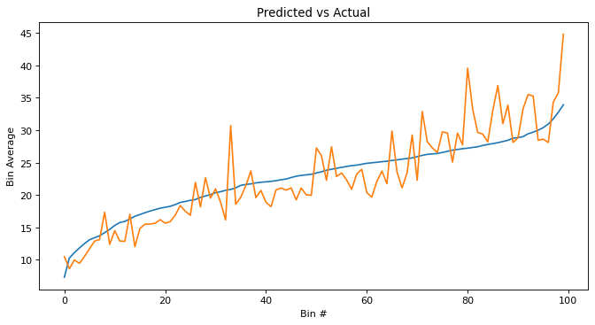

```python
'''
Below is the algorithm for stochastic gradient descent, but it is not finished :(

Add the following enhancements:
 1.  Shuffle the data before each iteration
 2.  Create batches for mini-batching
 3.  Create your own enhancement
'''

def sgd(x_, y_, max_iter=10000, learning_rt=.000001, batch_size=200, l1=.1, l2=.1):
    b_, intercept_ = ols(x_, y_)
    for i in range(max_iter):
        b_grad, intercept_grad = get_gradient(x_, y_, b_, intercept_, l1, l2)
        b_ -= b_grad * learning_rt
        intercept_ -= intercept_grad * learning_rt
    return b_, intercept_

optimizer_summary(sgd, X, y, name='Stochastic Gradient Descent')
```

```
Optimal Gradient Descent
   r_squared=       0.6186
   loss_mse=        32.1951
   loss_lasso=      32.4951
   loss_ridge=      39.9680
   loss_elasticnet= 36.2316
```

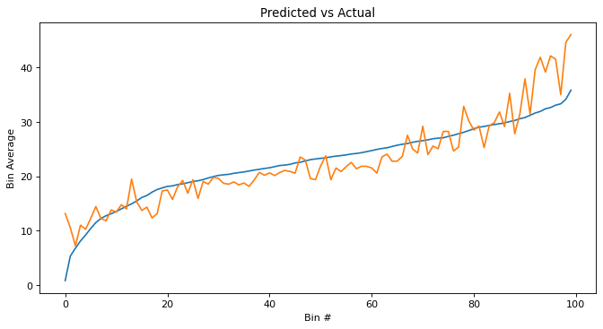

```python
# A major problem with stochastic gradient descent is optimizing the learning rate
# The following is a gradient descent optimizer that chooses an optimal learning rate for each step
def OptimalGradientDescent(x_, y_, max_iter=10000, l1=0, l2=0):
    b_, intercept_ = ols(x_, y_)
    alpha=l1+l2
    l1_ratio=0 if alpha==0 else l1/(l1+l2)
    coefs = np.r_[b_, [intercept_]]
    f_loss = (
        lambda lr:
        loss_elasticnet(
            linear_predict(X, b_-lr*b_grad, intercept_-lr*intercept_grad)
            , y, coefs, alpha, l1_ratio
        )
    )
    learning_rt = .0001
    for i in range(max_iter):
        b_grad, intercept_grad = get_gradient(x_, y_, b_, intercept_, l1, l2)
        log_lr = np.log(learning_rt)
        learning_rt = find_scale(f_loss, a=log_lr-5, b=log_lr+5, n=3)
        b_ -= b_grad * learning_rt
        intercept_ -= intercept_grad * learning_rt

    return b_, intercept_

optimizer_summary(OptimalGradientDescent, X, y, name='Optimal Gradient Descent')
```

#### Exercise 3

```python
'''
1. Create your own optimizer
2. Using all optimizers, tune hyper parameters to find the best linear model
3. Repeat 2, but also try all scalars built in previous notebook
'''
```

```
'\n1. Create your own optimizer\n2. Using all optimizers, tune hyper parameters to find the best linear model\n3. Repeat 2, but also try all scalars built in previous notebook\n'
```